# Homework Bonus

```r
library(randomForest)
require(MASS)
require(RFLPtools)
require(cluster)
require(factoextra)
```

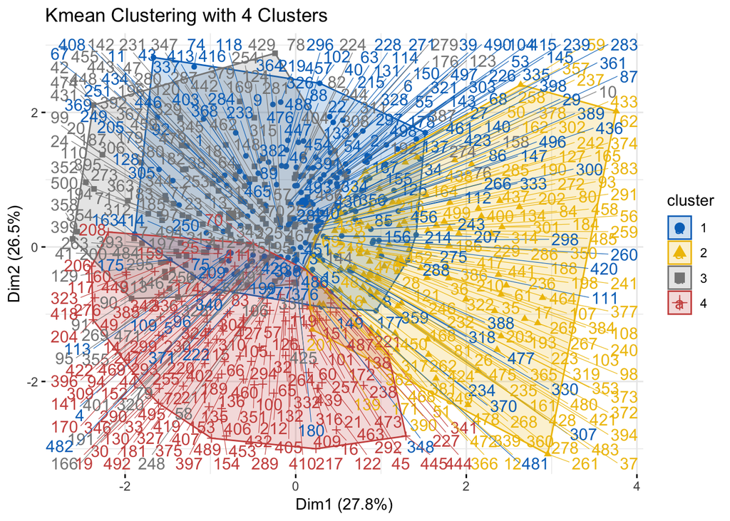

```r
knitr::opts_chunk$set(include = FALSE)
set.seed(71)

#generate 100 instances for class 1


# covmat=matrix(1,8,8)
# cov_val=runif(8)
# j=7
# for (i in 1:8)
# {
# covmat[i+j ,i]=cov_val[i]
# j=j-2
# }

#data generation
mu=c(1:4)
a=runif(4)
sigma=diag(0.8,4)
cl2=mvrnorm(500, mu,sigma)
cl2_scaled=scale(cl2)

#kmean clustering
clusters=kmeans(cl2,4)

#kmean visualization
fviz_cluster(clusters, data = cl2,
             ellipse.type = "convex",
             palette = "jco",
             repel = TRUE,
             ggtheme = theme_minimal(),
             main="Kmean Clustering with 4 Clusters")
```

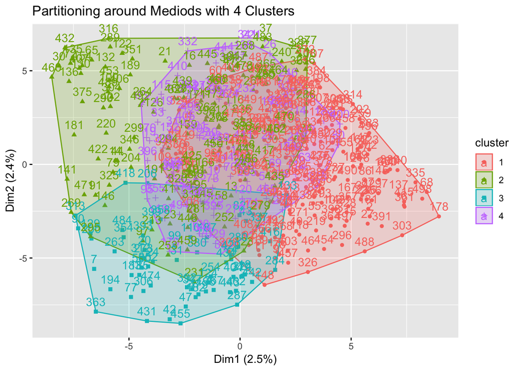

```r
#mean of kmean method
mean1_kmean=aggregate(cl2,by=list(clusters$cluster),FUN=mean)

#random forest
g <- randomForest(cl2_scaled, keep.forest=FALSE, proximity=TRUE)


pam.res=pam(g$proximity, 4, metric = "euclidean",diss=FALSE, stand = TRUE) #partitioning around medoids PAM
 fviz_cluster(pam.res, main = "Partitioning around Mediods with 4 Clusters")
```

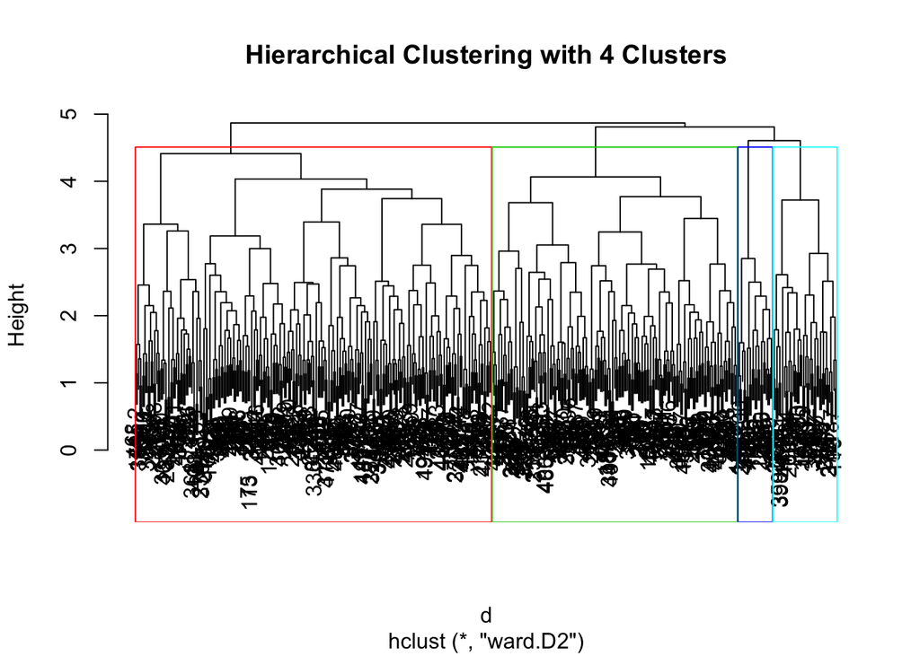

```r
 mean2_PAM=aggregate(cl2,by=list(pam.res$clustering),FUN=mean)


 #max(g$proximity)

  #hierarchical clustering with Ward’s method



# Ward Hierarchical Clustering
d <- dist(g$proximity, method = "euclidean") # distance matrix
fit <- hclust(d, method="ward.D2")

#fviz_dend(fit, cex = 0.5)

plot(fit, main ="Hierarchical Clustering with 4 Clusters" )

rect.hclust(fit, k=4, border=2:5)
```

```r
#mean3=aggregate(cl2,by=list(fit$height),FUN=mean)

mean1_kmean
```

```
##   Group.1        V1       V2       V3       V4
## 1       1 0.9505338 2.993797 3.005031 4.245555
## 2       2 0.7784673 1.440579 2.319814 4.773035
## 3       3 1.8909203 1.791456 2.985248 3.445876
## 4       4 0.4728381 1.471880 3.974681 3.737771
```

```r
mean2_PAM
```

```
##   Group.1        V1       V2       V3       V4
## 1       1 0.8454931 2.624003 2.804292 4.322015
## 2       2 0.6564673 1.161599 2.849482 3.739381
## 3       3 2.1573971 2.293526 3.288129 3.295687
## 4       4 1.2927642 1.607697 3.731531 4.445569
```

Mean of each parameter is set 1,2,3 and 4 respectively. When the mean of k_mean is compared to real mean value of the parameter we realize significant differences in the cluster means. Same trend is seen in the PAM results. When, the mean of the clusters are found for each parameter column, it is the same as the set mean value.

When the k-mean clustering is takes as bases the first graph is drawn. The clusters are nested. In the second method, which is PAM, the clusters are again nested.

For PAM, dissimilarity of random forest is found with euclidian metrics. Random forest is drawn according the scaled data. For PAM and Hierarchial clustering, scaled data is used to found the four clusters.

In Hierarchial Clustering, Ward’s method is used. The hclust function has to options for this method. ward.D2 is used because it includes Ward’s 1963 Criterion.

For this unsupervised learning problem, the dissimilarity of random forest is used. As known, clusters are best obtained when intrasimilairty is maximized, whereas intersimilarities are minimized. When dissimilarity of the random forest is found, clustering methods are expected to perform well in this problem. Since, random forests provide accuracy in the result of the problem, clustering results are expected to be accurate.

Additionally, since the accuracy is enhanced with random forests, adding noise to the data set should not create significant differences with the found clusters. (Breiman, Leo. “Random forests.” Machine learning 45.1 (2001): 5-32.)